# curvana: a comprehensive R package for analyzing atomic force microscopy force–distance curves

Minimal workflow

Yue (Gary) Zhang, PhD

2026-09-16

```r
knitr::opts_chunk$set(warning = T, message = T,echo = T)
```

# Introduction

This vignette presents a minimal workflow for analyzing data, from loading raw curves to generating summary statistics and visualizations. For a step-by-step demonstration of the full analytical workflow, see `vignette_full_workflow.html`.

# Preparation

## Initializing the work environment

```r
#required_packages = c('curvana', 'ggplot2', 'DT', 'dplyr', 'cowplot')
required_packages = c('curvana', 'ggplot2', 'dplyr', 'cowplot')
optional_packages = c('DT', 'ggpubr')


missing_required <- required_packages[!vapply(required_packages, requireNamespace, logical(1), quietly = TRUE)]
if (length(missing_required) > 0) {
  stop('Please install required packages first: ', paste(missing_required, collapse = ', '))
}

invisible(suppressPackageStartupMessages({
  lapply(required_packages, library, character.only = TRUE)
}))

available_optional <- optional_packages[vapply(optional_packages, requireNamespace, logical(1), quietly = TRUE)]
if (length(available_optional) > 0) {
  invisible(suppressPackageStartupMessages({
    lapply(available_optional, library, character.only = TRUE)
  }))
} else {
  message("Optional package 'ggpubr' is not installed; statistical annotation examples will be skipped.")
}

source(system.file("tutorial_helpers.R", package = "curvana"))
```

# Load data

## Example of raw curve data file

Below is an example input file. It contains two columns, “Calc_Ramp_Ex_nm” and “Defl_V_Ex”, which represent the piezo displacement in nm and cantilever deflection in V for the approach segment of the curve, respectively. The file also includes the columns “Calc_Ramp_Rt_nm” and “Defl_V_Rt” for the retract segment.

**Note that in the default Bruker AFM output format, the contact region is at the end of the curve (right side) and the non-interaction region is at the beginning (left side). By convention, however, the contact region is usually placed at the beginning of the curve and the non-interaction region at the end, which is also the required format of curvana. To correct this, set `reverse = TRUE` for the corresponding columns, as shown in the next section.**

```r
curve_path <- system.file("extdata", "F_1.spm-F4E1_ForceCurveIndex_0.spm.txt", package = "curvana")
curve_df <- read.table(curve_path, header = TRUE, sep = "\t")
view_df(curve_df,'Example raw curve data')
```

|  | Calc_Ramp_Ex_nm | Calc_Ramp_Rt_nm | Defl_V_Ex | Defl_V_Rt | X |
| --- | --- | --- | --- | --- | --- |
| 1 | 0 | 499.0234 | -0.23025 | 0.06937712 |  |
| 2 | 0.9765625 | 498.0469 | -0.2325 | 0.05212659 |  |
| 3 | 1.953125 | 497.0703 | -0.23175 | 0.03450105 |  |
| 4 | 2.929688 | 496.0938 | -0.229125 | 0.01725053 |  |
| 5 | 3.90625 | 495.1172 | -0.228 | -0.00075 |  |
| 6 | 4.882813 | 494.1406 | -0.232125 | -0.018 |  |
| 7 | 5.859375 | 493.1641 | -0.231375 | -0.034875 |  |
| 8 | 6.835938 | 492.1875 | -0.229125 | -0.05325 |  |
| 9 | 7.8125 | 491.2109 | -0.23025 | -0.070875 |  |
| 10 | 8.789063 | 490.2344 | -0.229125 | -0.09 |  |

[output cut: 502 more lines]

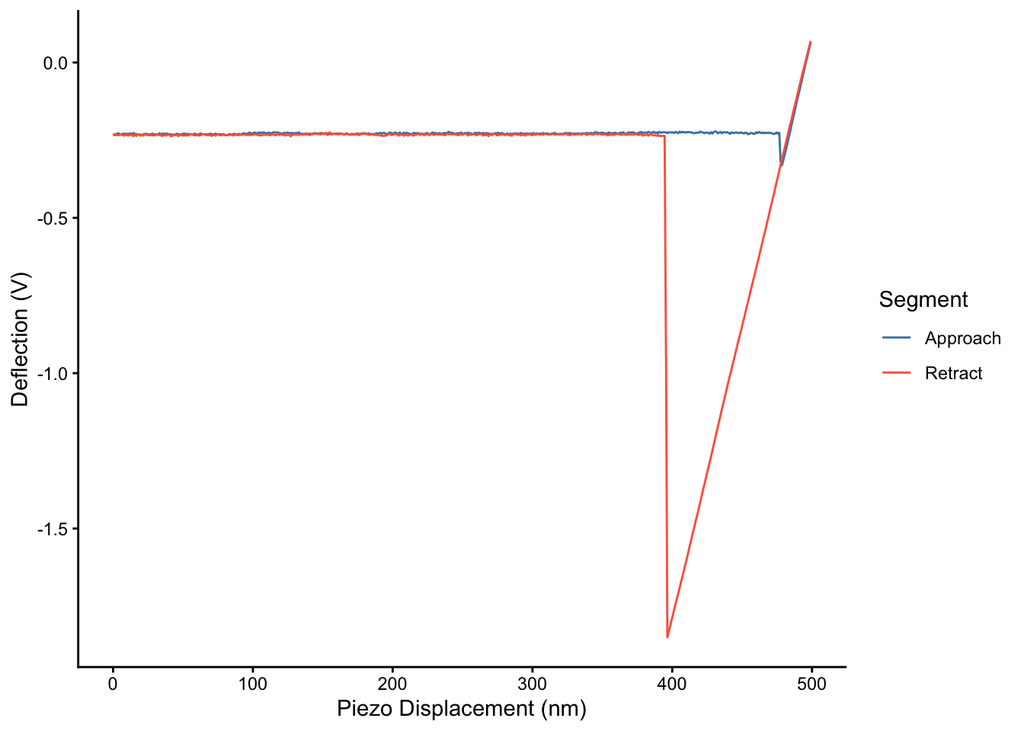

```r
print(ggplot(curve_df) +
  geom_line(aes(x = Calc_Ramp_Ex_nm, y = Defl_V_Ex, color = "Approach")) +
  geom_line(aes(x = Calc_Ramp_Rt_nm, y = Defl_V_Rt, color = "Retract")) +
  scale_color_manual(values = c("Approach" = "steelblue", "Retract" = "tomato")) +
  labs(x = "Piezo Displacement (nm)", y = "Deflection (V)", color = "Segment") +
  theme_classic())
```

## Load demo data

All examples below use the demo dataset provided in `extdata/` within the package. This folder contains approximately 100 raw curve files exported from Bruker NanoScope Analysis with both approach and retract segments included. To use your own dataset, pass the path to the directory containing the data to the `folder` argument. Users can increase `threads` to enable parallel processing when loading a large folder, for example, more than 10000 curves, which can substantially reduce computation time.

In this step, we initialize an fdObj by importing the demo data directory `extdata/` with `createFdObjFromFolder()`. An fdObj is the core data container in curvana. It stores atomic force microscopy (AFM) force-distance curve data, including raw curves, transformed data, associated metadata for downstream analysis, and the analytical metrics generated.

### Bruker/Veeco-style ASCII

Use `createFdObjFromFolder()` for generic Bruker/Veeco-style column-separated files. By default, the function reads all `.txt` files (or `.csv` if `suffix = ".csv"`) and removes lines starting with `#` or `"` before import. It expects at least one valid segment (approach or retract) with displacement and deflection columns. The default Bruker column names are `Calc_Ramp_Ex_nm`, `Defl_V_Ex`, `Calc_Ramp_Rt_nm`, and `Defl_V_Rt`, but these can be replaced with custom headers for other exports. If contact and non-interaction regions are in the opposite orientation, use the `reverse_*` arguments to correct direction. If users have only approach or retract data, they can still use this function to create an fdObj by specifying column names only for the available segment and leaving the arguments for the missing segment unchanged. The function will automatically ignore the missing segment and create an fdObj containing only the available data.

```r
folder = system.file("extdata", package = "curvana")
test.input = createFdObjFromFolder(folder = folder,
                                  Displacement_Approach = "Calc_Ramp_Ex_nm", # column name for piezo displacement in the approach curve
                                  Deflection_Approach = "Defl_V_Ex", # column name for cantilever deflection in the approach curve
                                  Displacement_Retract = "Calc_Ramp_Rt_nm", # column name for piezo displacement in the retract curve
                                  Deflection_Retract = "Defl_V_Rt", # column name for cantilever deflection in the retract curve
                                  reverse_Displacement_Approach = FALSE, # set to FALSE to keep the piezo displacement column for the approach curve as is
                                  reverse_Displacement_Retract = TRUE, # set to TRUE to reverse the piezo displacement column for the retract curve
                                  reverse_Deflection_Approach = TRUE, # set to TRUE to reverse the cantilever deflection column for the approach curve
                                  reverse_Deflection_Retract = FALSE # set to FALSE to keep the cantilever deflection column for the retract curve as is
                                  )
```

### JPK-style ASCII

For JPK ASCII exports, use the dedicated importer `createFdObjFromJPKFolder()` instead of `createFdObjFromFolder()`. The JPK importer automatically detects approach/retract segments, parses spring constant and sensitivity, and converts force data back to Voltage when needed. Users are encouraged to directly import raw deflection voltage in analysis.

Specifically, `createFdObjFromJPKFolder()`:

- Detects approach and retract segments automatically
- Parses sensitivity and spring constant for each segment; if deflection is in force units (N), converts it back to voltage
- Converts distance to nm, applies optional segment reversal, and records imported parameters plus datapoint counts in metadata

```r
# For JPK ASCII data, use the JPK-specific importer:
jpk_folder <- system.file("extdata_jpk", package = "curvana")

test.input.jpk <- createFdObjFromJPKFolder(
  folder = jpk_folder,
  height_col = "height",
  deflection_col = "vDeflection"
)
```

```r
print(test.input)
```

```
## An object of class "fdObj"
## ----------------------------------------
## Samples registered:  101
## Raw curves imported:  101
## Transformed approach curves:  0
## Transformed retract curves:   0
##
## Metadata columns:
##   - filename
##   - Number_of_datapoints_approach
##   - Number_of_datapoints_retract
```

```r
view_df(test.input@metadata,'metadata')
```

|  | filename | Number_of_datapoints_approach | Number_of_datapoints_retract |
| --- | --- | --- | --- |
| F_1.spm-F4E1_ForceCurveIndex_0.spm | F_1.spm-F4E1_ForceCurveIndex_0.spm | 512 | 512 |
| F_1.spm-F4E1_ForceCurveIndex_1.spm | F_1.spm-F4E1_ForceCurveIndex_1.spm | 512 | 512 |
| F_1.spm-F4E1_ForceCurveIndex_10.spm | F_1.spm-F4E1_ForceCurveIndex_10.spm | 512 | 512 |
| F_1.spm-F4E1_ForceCurveIndex_2.spm | F_1.spm-F4E1_ForceCurveIndex_2.spm | 512 | 512 |
| F_1.spm-F4E1_ForceCurveIndex_3.spm | F_1.spm-F4E1_ForceCurveIndex_3.spm | 512 | 512 |
| F_1.spm-F4E1_ForceCurveIndex_4.spm | F_1.spm-F4E1_ForceCurveIndex_4.spm | 512 | 512 |
| F_1.spm-F4E1_ForceCurveIndex_5.spm | F_1.spm-F4E1_ForceCurveIndex_5.spm | 512 | 512 |
| F_1.spm-F4E1_ForceCurveIndex_6.spm | F_1.spm-F4E1_ForceCurveIndex_6.spm | 512 | 512 |
| F_1.spm-F4E1_ForceCurveIndex_7.spm | F_1.spm-F4E1_ForceCurveIndex_7.spm | 512 | 512 |
| F_1.spm-F4E1_ForceCurveIndex_8.spm | F_1.spm-F4E1_ForceCurveIndex_8.spm | 512 | 512 |

[output cut: 91 more lines]

Extract sample groups from the names of the imported raw curve files.

```r
test <- test.input
test@metadata <- test@metadata %>%
  mutate(surface = sub("_.*","",filename),
         surface = case_when(
        surface == 'F' ~ 'Group_A',
        surface == 'P' ~ 'Group_B',
        surface == 'silicon' ~ 'Group_C',
        surface == 'Z' ~ 'Group_D',
            TRUE ~ surface),
         region = sub(".*?_([0-9]+)\\.spm.*", "\\1", filename)
  )
view_df(test@metadata,'metadata')
```

|  | filename | Number_of_datapoints_approach | Number_of_datapoints_retract | surface | region |
| --- | --- | --- | --- | --- | --- |
| F_1.spm-F4E1_ForceCurveIndex_0.spm | F_1.spm-F4E1_ForceCurveIndex_0.spm | 512 | 512 | Group_A | 1 |
| F_1.spm-F4E1_ForceCurveIndex_1.spm | F_1.spm-F4E1_ForceCurveIndex_1.spm | 512 | 512 | Group_A | 1 |
| F_1.spm-F4E1_ForceCurveIndex_10.spm | F_1.spm-F4E1_ForceCurveIndex_10.spm | 512 | 512 | Group_A | 1 |
| F_1.spm-F4E1_ForceCurveIndex_2.spm | F_1.spm-F4E1_ForceCurveIndex_2.spm | 512 | 512 | Group_A | 1 |
| F_1.spm-F4E1_ForceCurveIndex_3.spm | F_1.spm-F4E1_ForceCurveIndex_3.spm | 512 | 512 | Group_A | 1 |
| F_1.spm-F4E1_ForceCurveIndex_4.spm | F_1.spm-F4E1_ForceCurveIndex_4.spm | 512 | 512 | Group_A | 1 |
| F_1.spm-F4E1_ForceCurveIndex_5.spm | F_1.spm-F4E1_ForceCurveIndex_5.spm | 512 | 512 | Group_A | 1 |
| F_1.spm-F4E1_ForceCurveIndex_6.spm | F_1.spm-F4E1_ForceCurveIndex_6.spm | 512 | 512 | Group_A | 1 |
| F_1.spm-F4E1_ForceCurveIndex_7.spm | F_1.spm-F4E1_ForceCurveIndex_7.spm | 512 | 512 | Group_A | 1 |
| F_1.spm-F4E1_ForceCurveIndex_8.spm | F_1.spm-F4E1_ForceCurveIndex_8.spm | 512 | 512 | Group_A | 1 |

[output cut: 91 more lines]

```r
test_beforeTransform <- test
```

# Preview the raw deflection curves

It is important to inspect the raw curves before formal analysis. Here, we visualize them with scatter plots to examine their overall patterns.

## Deflection vs data point index

Here we use `plot_deflection_curves_by_index()` to plot raw deflection values against the row index (data point number) for each curve. This visualization helps us: - See how many data points are in each curve - Verify that the data is oriented in the correct direction (contact region at the beginning, non-interaction region at the end) - Help us with selecting the appropriate regions for baseline calibration and sensitivity calculation in the next step.

We split curves into subpanels by `surface` and color-code them by `region`.

```
## 101 samples in the input; 101 approach and 101 retract curves are plotted.
```

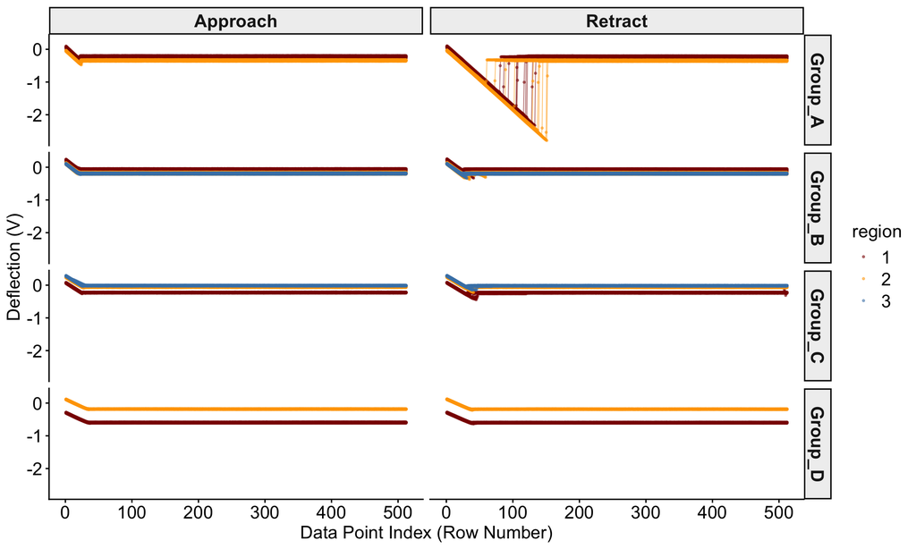

```r
plot_deflection_curves_by_index(test,split_curves_by = 'surface',group_curves_by = 'region',
                       alpha = 0.5,point_size = 0.5,
                       color_map = list(`1` = 'darkred',
                                        `2` = 'orange',
                                        `3` = 'steelblue'))
```

## Scatter plot of deflection curves

We can use `plot_deflection_curves()` to plot curves in batch. Here, we split curves into subpanels by `surface` and color-code them by `region`.

```
## 101 samples in the input; 101 approach and 101 retract curves are plotted.
```

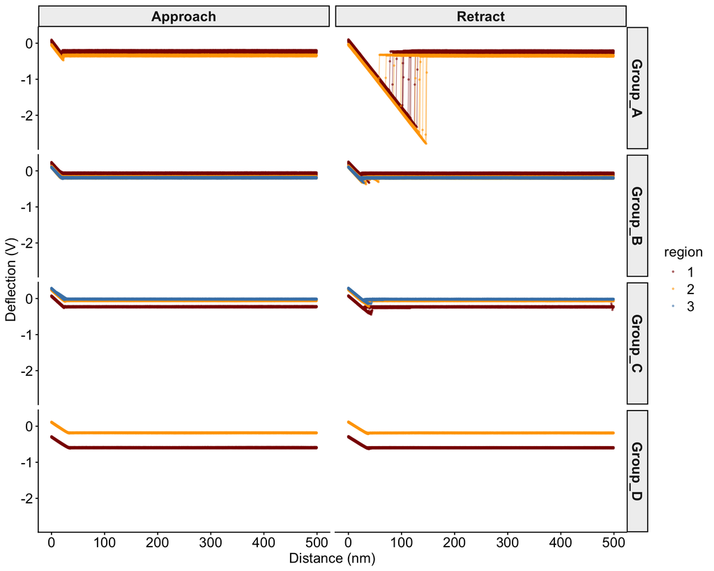

```r
plot_deflection_curves(test,split_curves_by = 'surface',group_curves_by = 'region',
                       alpha = 0.5,point_size = 0.5,
                       color_map = list(`1` = 'darkred',
                                        `2` = 'orange',
                                        `3` = 'steelblue'))
```

# Curve transformation

Curve transformation in curvana involves several steps, including smoothing, sensitivity calculation, baseline offset calculation, and application of these parameters to convert raw data into interaction force-separation distance curves. To execute all necessary steps at once, we can use the convenience function `transform_curves()`.

```r
# transformation for the approach curves
test = transform_curves(test,
                        useCurve = 'approach', # analyze the approach curve

                        denoise_first = TRUE, # whether to denoise raw curves before transformation. Denoising can improve the reliability of sensitivity and baseline calculations, especially for noisy curves. The smoothed curve will be used for downstream analysis, while the original raw curve will be preserved in the rawCurves slot for reference.
                        p = 1, n = 3, # parameters for the Savitzky-Golay filter used for denoising. p is the polynomial order (default 1, meaning linear), and n is the window size (default 3, meaning each point is smoothed by fitting a polynomial to itself and its 2 neighbors). Users can adjust these parameters based on curve noise and shape. This setting is equivalent to a simple moving average.

                        spring_constant = 0.08, # spring constant; can be a single numeric value applied to all curves, or the name of a metadata column containing per-curve spring constant values.

                        # baseline determination and filtering
                        least_length = 300, # use the last (right side) 300 points as baseline
                        slp_threshold = 0.01, # any curve with a baseline-region slope > 0.01 will be discarded
                        std_threshold = 0.01, # any curve with a baseline-region standard deviation of y values > 0.01 will be discarded

                        # sensitivity calibration
                        intv = 4, # number of data points added per iteration when building the linear sensitivity segment
                        end = 20, # use at most the first 20 data points on the left side of the curve to calculate sensitivity
                        R_squared_min = 0.99, # minimum R^2 threshold for accepting a segment as sufficiently linear during sensitivity calculation
                        minimum_length = 4 # minimum number of accumulated points required for a valid sensitivity result; if shorter, sensitivity is reported as NA
                        )
```

```
## Denoised 101 raw curves (useCurve = 'approach').
```

```
## Using fixed spring constant: 0.0800 nN/nm (stored in metadata$spring_constant).
```

```
## Column 'sensitivity_V_nm_approach' not found in metadata. Running analyze_sensitivity()...
```

```
## Processed 101 curves; 0 failed sensitivity calculation.
```

```
## Column 'baseline_V_approach' not found in metadata. Running analyze_baseline()...
```

```
## Processed 101 curves; 7 failed baseline detection.
```

```
## Processed 101 curves (approach); 7 failed transformation.
```

```r
# repeat the same transformation for the retract curves
test = transform_curves(test,
                        useCurve = 'retract', # analyze the retract curve

                        denoise_first = TRUE,
                        p = 1, n = 3,
                        spring_constant = 0.08,
                        # baseline determination and filtering
                        least_length = 300,
                        slp_threshold = 0.01,
                        std_threshold = 0.01,
                        # sensitivity calibration
                        intv = 4,
                        end = 20,
                        R_squared_min = 0.99,
                        minimum_length = 4
                        )
```

```
## Denoised 101 raw curves (useCurve = 'retract').
```

```
## Using fixed spring constant: 0.0800 nN/nm (stored in metadata$spring_constant).
```

```
## Column 'sensitivity_V_nm_retract' not found in metadata. Running analyze_sensitivity()...
```

```
## Processed 101 curves; 0 failed sensitivity calculation.
```

```
## Column 'baseline_V_retract' not found in metadata. Running analyze_baseline()...
```

```
## Processed 101 curves; 9 failed baseline detection.
```

```
## Processed 101 curves (retract); 9 failed transformation.
```

## Soft surface correction

**When measuring on a compliant (soft) surface, such as a hydrogel, cell membrane, or polymer brush, the contact region of the curve reflects a combined response from both cantilever deflection and surface indentation. Using this region to estimate probe sensitivity will therefore underestimate the true probe sensitivity. To correct for this, the probe sensitivity should be calibrated separately on a rigid reference surface (for example, bare glass or silicon) and then supplied to `transform_curves()` when processing soft-surface curves.**

**To do this, set `soft = TRUE` and provide the externally calibrated sensitivity via `probe_sensitivity_external`. This can be either a single numeric value, applied to all curves, or the name of a metadata column containing per-curve sensitivity values. When `soft = TRUE`, `transform_curves()` uses this external sensitivity to convert deflection (V) to force (nN). Note that the x-axis transformation, from piezo displacement to separation distance, is unaffected and always uses the sensitivity estimated from each individual curve, preserving the deformation component in the separation distance.**

```r
test3 = transform_curves(test,
                        useCurve = 'retract', # analyze the retract curve
                        denoise_first = TRUE,
                        p = 1, n = 3,
                        spring_constant = 0.08,
                        # baseline determination and filtering
                        least_length = 300,
                        std_threshold = 0.01,
                        slp_threshold = 0.01,
                        # sensitivity calibration
                        intv = 4,
                        end = 20,
                        R_squared_min = 0.99,
                        minimum_length = 4,
                        # soft surface correction
                        soft = TRUE, # whether to apply soft surface correction
                        probe_sensitivity_external = 0.05 # externally calibrated sensitivity value to use for soft surface correction (in V/nm). This can be a single numeric value applied to all curves, or the name of a metadata column containing per-curve sensitivity values.
                        )
```

```
## Using fixed probe sensitivity: 0.05 (stored in metadata$probe_true_sensitivity_V_nm_retract).
```

```
## Denoised 101 raw curves (useCurve = 'retract').
```

```
## Using fixed spring constant: 0.0800 nN/nm (stored in metadata$spring_constant).
```

```
## Processed 101 curves (retract); 9 failed transformation.
```

# Plot transformed curves

To visualize the transformed curves, we can use `plot_fd_curves()`. Here, we plot the approach and retract curves in separate panels and color-code them by `region`.

```
## 101 samples in the input; 94 approach and 92 retract curves are plotted.
```

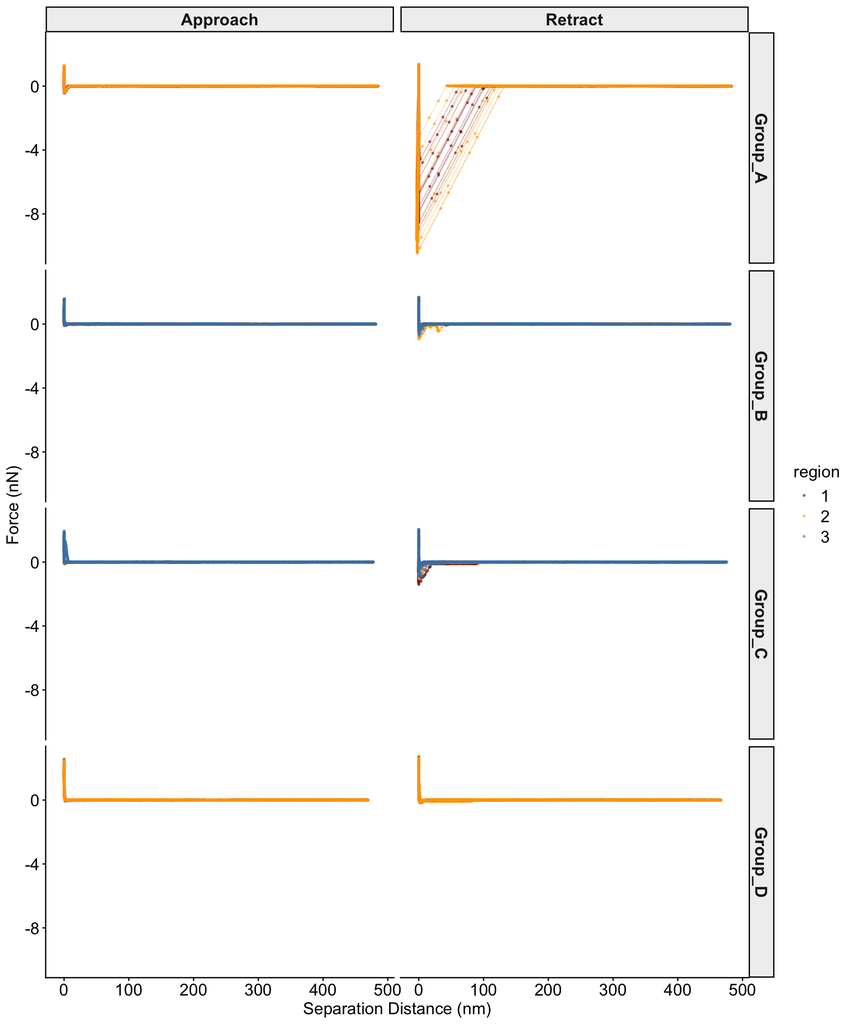

```r
plot_fd_curves(test,group_curves_by = 'region', split_curves_by = 'surface',
               point_alpha = 0.5,line_alpha = 0.3, point_size = 0.5,
               color_map = list(`1` = 'darkred',
                                `2` = 'orange',
                                `3` = 'steelblue'))
```

We can see that Group_A has the largest adhesion, which occurs mostly immediately after the probe is pulled off the surface. The other groups also show adhesion, but at lower magnitudes. All curves that passed the transformation step have baselines that are well aligned with the zero-force line and show relatively small fluctuations, which is important for accurate calculation of analytical metrics in later steps.

# Analytical metrics calculation

`analyze_curves_all_analytical_metrics()` is a wrapper function that calculates all analytical metrics at once. It first determines a baseline noise level so that insignificant fluctuations can be excluded from metric calculations. It then determines adhesive force, adhesive and repulsive energy, and adhesive (rupture) and repulsive distance.

```r
test = analyze_curves_all_analytical_metrics(
  test, # the object
  useCurve = "both", # run analysis for both approach and retract

  # noise band parameters
  noise_baseline_span = "automatic", # use the baseline section previously defined in curve transformation for noise band calculation
  noise_threshold_method = "quantile", # use quantile method to define the noise band
  noise_quantile_low = 0.00, # define the lower end of noise band as minimum y value of the baseline section
  noise_quantile_high = 1, # define the upper end of noise band as maximum y value of the baseline section
  noise_multiplier = 1, # multiply the noise band by 1 to directly use the min-max range of the force in baseline region without further scaling.

  # adhesive force
  analyze_adhesive_force = TRUE, # whether to analyze adhesive force
  # adhesive energy and repulsive energy
  analyze_energy = TRUE, # whether to analyze interaction energy (repulsive and adhesive)
  # rupture (adhesive) distance
  analyze_rupture_distance = TRUE, # whether to analyze adhesive/rupture distance
  # repulsive distance
  analyze_repulsive_distance = TRUE # whether to analyze repulsive distance
)
```

```
## Analyzing approach curves ...
```

```
## Noise bands analyzed for 101 curves (approach): 94 valid results.
```

```
## Adhesive force analyzed for 101 curves: 94 with adhesion, 0 with no adhesion (0), 7 not analyzed (NA).
```

```
## Energy analyzed for 101 curves (approach): 7 NA adhesive, 7 NA repulsive (units = aJ).
```

```
## Interaction distance analyzed for 101/101 curves (approach, rupture): 64 valid results.
```

```
## Interaction distance analyzed for 101/101 curves (approach, repulsive): 94 valid results.
```

```
## Analyzing retract curves ...
```

```
## Noise bands analyzed for 101 curves (retract): 92 valid results.
```

```
## Adhesive force analyzed for 101 curves: 92 with adhesion, 0 with no adhesion (0), 9 not analyzed (NA).
```

```
## Energy analyzed for 101 curves (retract): 9 NA adhesive, 9 NA repulsive (units = aJ).
```

```
## Interaction distance analyzed for 101/101 curves (retract, rupture): 89 valid results.
```

```
## Interaction distance analyzed for 101/101 curves (retract, repulsive): 92 valid results.
```

All calculated analytical metrics will be stored in the metadata table of the fdObj, and can be accessed by `test@metadata`. The names of columns for each metric are self-explanatory, and include the metric name, the unit, and the curve type used for analysis (approach or retract).

```r
view_df(test@metadata,'metadata')
```

|  | filename | Number_of_datapoints_approach | Number_of_datapoints_retract | surface | region | spring_constant | sensitivity_V_nm_approach | baseline_V_approach | baseline_span_approach | sensitivity_V_nm_retract | baseline_V_retract | baseline_span_retract | noiseBand_low_nN_approach | noiseBand_high_nN_approach | adhesive_force_nN_approach | adhesive_sep_nm_approach | adhesive_energy_aJ_approach | repulsive_energy_aJ_approach | rupture_distance_nm_approach | rupture_threshold_nN_approach | repulsive_distance_nm_approach | repulsive_threshold_nN_approach | noiseBand_low_nN_retract | noiseBand_high_nN_retract | adhesive_force_nN_retract | adhesive_sep_nm_retract | adhesive_energy_aJ_retract | repulsive_energy_aJ_retract | rupture_distance_nm_retract | … |
| --- | --- | --- | --- | --- | --- | --- | --- | --- | --- | --- | --- | --- | --- | --- | --- | --- | --- | --- | --- | --- | --- | --- | --- | --- | --- | --- | --- | --- | --- | --- |
| F_1.spm-F4E1_ForceCurveIndex_0.spm | F_1.spm-F4E1_ForceCurveIndex_0.spm | 512 | 512 | Group_A | 1 | 0.08 | 0.01953175268173134 | -0.22915625 | 300 | 0.0185355755023641 | -0.2324710416666667 | 300 | -0.01932750256217852 | 0.01702356185940229 | 0.3782302653724345 | 0.659649033612661 | 1.52126866074192 | 0.1419465887645222 | 5.825496346928436 | -0.01932750256217852 | 0 | 0.01702356185940229 | -0.01469156793280754 | 0.01983662893479835 | 6.906303861476515 | -1.179719620789371 | 302.5896719903102 | 0.1498346591159349 | 90.79111510625344 | … |
| F_1.spm-F4E1_ForceCurveIndex_1.spm | F_1.spm-F4E1_ForceCurveIndex_1.spm | 512 | 512 | Group_A | 1 | 0.08 | 0.01919879781109477 | -0.2264658333333334 | 300 | 0.01851595098597184 | -0.2322664583333333 | 300 | -0.01785181221791217 | 0.01496274243279231 | 0.412147333973206 | 0.554440545163823 | 1.757585710250056 | 0.05905711714112136 | 5.932264145614361 | -0.01785181221791217 | 0 | 0.01496274243279231 | -0.01937158580756028 | 0.01789358088697035 | 4.599206565077417 | 2.067224738593488 | 148.0256565540194 | 0.06232472005157359 | 57.71496392656269 | … |
| F_1.spm-F4E1_ForceCurveIndex_10.spm | F_1.spm-F4E1_ForceCurveIndex_10.spm | 512 | 512 | Group_A | 1 | 0.08 | 0.01938341015922519 | -0.2568625 | 300 | 0.01848164144586605 | -0.261550625 | 300 | -0.01294921780729807 | 0.0138778469727618 | 0.2714176688613339 | -0.01021749154837615 | 0.8493891001364311 | 0.2108330117525492 | 3.780814398431669 | -0.01294921780729807 | 0.03020646167193397 | 0.0138778469727618 | -0.01709534301514488 | 0.01536930585045726 | 7.916285489497233 | -1.04299005306288 | 395.1555769889826 | 0.09551617824244871 | 98.66518090899976 | … |
| F_1.spm-F4E1_ForceCurveIndex_2.spm | F_1.spm-F4E1_ForceCurveIndex_2.spm | 512 | 512 | Group_A | 1 | 0.08 | 0.0184777721502696 | -0.2240177083333333 | 300 | 0.01877256318423071 | -0.2283635416666667 | 300 | -0.01561786404694485 | 0.01847715535672323 | 0.382545215724516 | 0.2712855694773326 | 1.569244779401465 | 0.1827608201429701 | 183.5553376958423 | -0.01561786404694485 | 0 | 0.01847715535672323 | -0.01656229166019496 | 0.01220309294394968 | 5.821843058622542 | 0.2519295723933936 | 221.4383955617098 | 0.3573062487541803 | 72.33173973768058 | … |
| F_1.spm-F4E1_ForceCurveIndex_3.spm | F_1.spm-F4E1_ForceCurveIndex_3.spm | 512 | 512 | Group_A | 1 | 0.08 | 0.01864995710405837 | -0.2190122916666667 | 300 | 0.01876507451418484 | -0.2244814583333334 | 300 | -0.01174354801164691 | 0.01613855365210664 | 0.321663831889524 | 0.1087491306858839 | 1.323165096551329 | 0.1939456927756851 | 5.987507575890596 | -0.01174354801164691 | 0.01147292585898607 | 0.01613855365210664 | -0.02032943344003056 | 0.01697390897253812 | 8.533485076879776 | 0.1886820468661483 | 475.3704726044384 | 0.07745105180938809 | 93.31253495154075 | … |
| F_1.spm-F4E1_ForceCurveIndex_4.spm | F_1.spm-F4E1_ForceCurveIndex_4.spm | 512 | 512 | Group_A | 1 | 0.08 | 0.01958435316127593 | -0.2118975 | 300 | 0.01860802118930836 | -0.2193322916666667 | 300 | -0.01114154744877893 | 0.009793532542052254 | 0.2807445287941179 | 0.7876340354183662 | 1.084715402761747 | 0.1100549495946918 | 190.6810813022351 | -0.01114154744877893 | 0 | 0.009793532542052254 | -0.01523088692684369 | 0.01432625912348507 | 8.998991078260417 | -0.9179925102257585 | 512.68500103552 | 0.1053258910889671 | 105.1930173381948 | … |
| F_1.spm-F4E1_ForceCurveIndex_5.spm | F_1.spm-F4E1_ForceCurveIndex_5.spm | 512 | 512 | Group_A | 1 | 0.08 | 0.01974969378924028 | -0.208544375 | 300 | 0.01855071135453553 | -0.2122558333333334 | 300 | -0.01501035930802666 | 0.0123318367666383 | 0.4433714311444439 | 0.9714866744980615 | 2.130108121234758 | 0.1677814338697816 | 6.89936184461139 | -0.01501035930802666 | 0 | 0.0123318367666383 | -0.01075610145184799 | 0.01296266553184631 | 6.964128267876226 | -2.583268136373974 | 298.1984910103744 | 0.1684038600592396 | 81.2462944790333 | … |
| F_1.spm-F4E1_ForceCurveIndex_6.spm | F_1.spm-F4E1_ForceCurveIndex_6.spm | 512 | 512 | Group_A | 1 | 0.08 | 0.0190822422605573 | -0.2024758333333334 | 300 | 0.01838381145447972 | -0.2084514583333334 | 300 | -0.01529869128308656 | 0.01457201218126378 | 0.2259657578211357 | 0.8605916638243127 | 0.7174156161736311 | 0.2225469546352301 | 5.021261459325635 | -0.01529869128308656 | 0 | 0.01457201218126378 | -0.02088159652223743 | 0.01556351180902406 | 7.653140029297319 | -1.199673488263684 | 370.3267847904337 | 0.120046537620812 | 82.8203925487932 | … |
| F_1.spm-F4E1_ForceCurveIndex_7.spm | F_1.spm-F4E1_ForceCurveIndex_7.spm | 512 | 512 | Group_A | 1 | 0.08 | 0.01926291314275661 | -0.1937797916666667 | 300 | 0.01838945375728929 | -0.201685625 | 300 | -0.01389284500653511 | 0.01362116578052459 | 0.2651528680430804 | 0.09308986648792139 | 0.9628588646084485 | 0.07162324765475368 | 5.57950634056847 | -0.01389284500653511 | 0 | 0.01362116578052459 | -0.01496238026596818 | 0.01548985651012559 | 8.10492535380073 | -1.925612474940749 | 408.2712373597486 | 0.1327429563330381 | 100.4156863755885 | … |
| F_1.spm-F4E1_ForceCurveIndex_8.spm | F_1.spm-F4E1_ForceCurveIndex_8.spm | 512 | 512 | Group_A | 1 | 0.08 | 0.01846043987251427 | -0.2695852083333334 | 300 | 0.01815902925417498 | -0.2802514583333334 | 300 | -0.01696510676322667 | 0.01607852622778498 | 0.2287693772465967 | -0.1378864240375388 | 0.7368991794281446 | 0.1441013868813086 | 140.1913944844673 | -0.01696510676322667 | 0 | 0.01607852622778498 | -0.01871704310709173 | 0.02093265346655435 | 6.805423439962841 | -2.422922523180731 | 287.7469247247797 | 0.1869763214766936 | 59.19660875926827 | … |

[output cut: 91 more lines]

# View selected curves with metrics annotated

To visualize curves with analytical metrics annotated, we can use `plot_a_curve_metrics()`. Here, we plot the retract curve of a selected sample and set `plot_raw = TRUE` to display the raw data side by side with the annotated metrics.

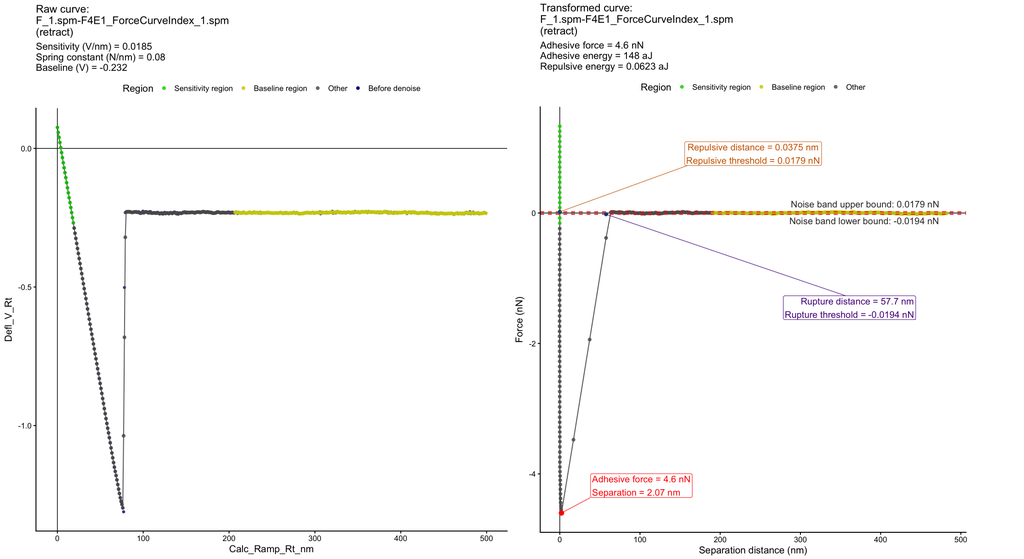

```r
plot_a_curve_metrics(
  fdobj = test,
  curve_name = 'F_1.spm-F4E1_ForceCurveIndex_1.spm' ,
  useCurve = "retract", # which curve to plot, can be "approach" or "retract".
  plot_raw = T, # whether to plot the raw curve together with the transformed curve.
  base_size = 15,
  annotation_text_size = 5
)
```

# Save all raw and transformed curves with analytical metrics annotated (optional)

```r
plot_all_curve_metrics(
  fdobj = test, # the fdObj to plot
  useCurve = "retract", # plot the retract curve
  plot_raw = T, # whether to plot the raw curve
  destination_folder = '../test_plot_metrics_denoised', # the path to save the plots
  format = 'png', width = 18, height = 9, # plot format and dimensions
  threads = 8 # number of threads to use for parallel processing (set to 8 to use 8 cores, which will significantly speed up the plotting process for a large dataset
)
plot_all_curve_metrics(
  fdobj = test, # the fdObj to plot
  useCurve = "approach", # plot the approach curve
  plot_raw = T, # whether to plot the raw curve
  destination_folder = '../test_plot_metrics_denoised', # the path to save the plots
  format = 'png', width = 18, height = 9, # plot format and dimensions
  threads = 8 # number of threads to use for parallel processing (set to 8 to use 8 cores, which will significantly speed up the plotting process for a large dataset
)
```

# Summary statistics of analytical metrics

## PCA biplot of selected metrics

Dimensionality reduction is first used to visualize the overall pattern of how curves cluster based on their analytical metrics. The function `plot_pca_biplot()` performs principal component analysis (PCA) on the selected metrics and plots sample scores in PCA space, colored by a specified metadata variable such as surface type. The function also plots feature loadings as arrows, indicating how each metric contributes to the principal components and the clustering pattern of samples.

```
## Dropped 17 row(s) with missing/non-finite feature values or missing color group.
```

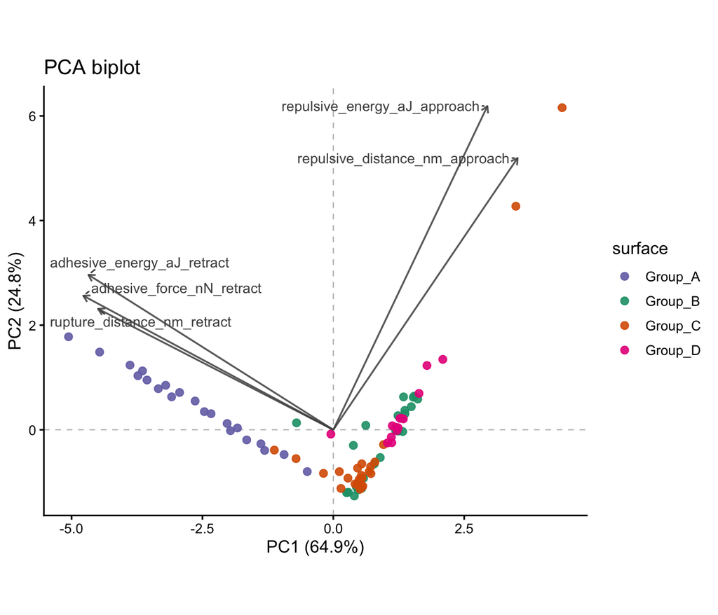

```r
pca_features <- c(
  "adhesive_force_nN_retract",
  "adhesive_energy_aJ_retract",
  "rupture_distance_nm_retract",
  "repulsive_energy_aJ_approach",
  "repulsive_distance_nm_approach"
)

plot_pca_biplot(
  df = test@metadata,
  include_columns = pca_features,
  color_by = "surface",
  color_map = c(
    Group_B = "#1b9e77",
    Group_C = "#d95f02",
    Group_A = "#7570b3",
    Group_D = "#e7298a"
  ),
  arrow_scale = 1.1,
  show_feature_labels = TRUE
)
```

## Scaled feature heatmap with sample annotations

```
## Dropped 17 row(s) with missing/non-numeric feature values.
```

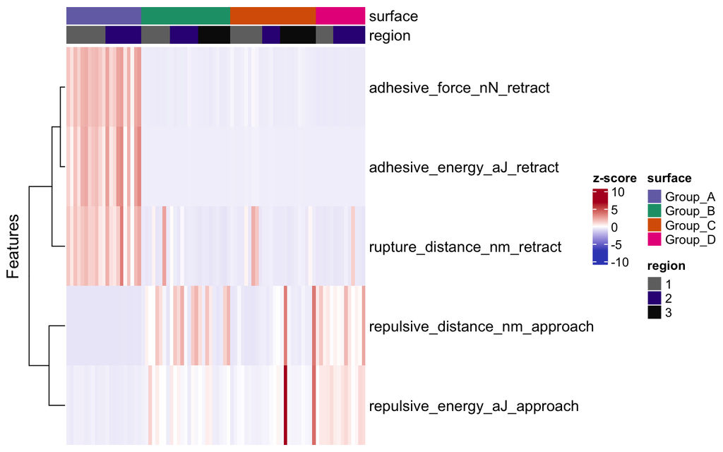

```r
  plot_complex_heatmap(
    df = test@metadata,
    include_columns = pca_features,
    annotate_columns = c("surface", "region"),
    annotation_colors = list(
      surface = c(
        Group_B = "#1b9e77",
        Group_C = "#d95f02",
        Group_A = "#7570b3",
        Group_D = "#e7298a"
      )
    ),
    cluster_rows = TRUE,
    cluster_columns = FALSE,
    show_row_dend = TRUE,
    show_column_dend = FALSE,
    heatmap_name = "z-score",
    show_column_names = FALSE
  )
```

## Violin plot of selected metrics by surface

`plot_metric_violin()` can be used to visualize the distribution of selected metrics across different groups. Here, we plot violin plots for adhesive force, adhesive energy, and rupture distance from the retract curves, as well as repulsive energy and repulsive distance from the approach curves. The option `show_whisker_box = TRUE` displays the median and interquartile range of each distribution.

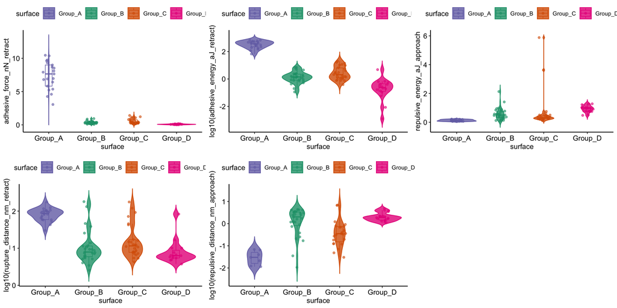

```r
f1 = plot_metric_violin(test@metadata, metric_name = "adhesive_force_nN_retract", group_by = "surface", color_map = c(Group_B = "#1b9e77", Group_C = "#d95f02", Group_A = "#7570b3", Group_D = "#e7298a"),
show_whisker_box = T)
f2 = plot_metric_violin(test@metadata, metric_name = "adhesive_energy_aJ_retract",log10=T,  group_by = "surface", color_map = c(Group_B = "#1b9e77", Group_C = "#d95f02", Group_A = "#7570b3", Group_D = "#e7298a"),
show_whisker_box = T)
f3 = plot_metric_violin(test@metadata, metric_name = "repulsive_energy_aJ_approach", group_by = "surface", color_map = c(Group_B = "#1b9e77", Group_C = "#d95f02", Group_A = "#7570b3", Group_D = "#e7298a"),
show_whisker_box = T)
f4 = plot_metric_violin(test@metadata, metric_name = "rupture_distance_nm_retract", log10=T, group_by = "surface", color_map = c(Group_B = "#1b9e77", Group_C = "#d95f02", Group_A = "#7570b3", Group_D = "#e7298a"),
show_whisker_box = T)
f5 = plot_metric_violin(test@metadata, metric_name = "repulsive_distance_nm_approach", log10=T, group_by = "surface", color_map = c(Group_B = "#1b9e77", Group_C = "#d95f02", Group_A = "#7570b3", Group_D = "#e7298a"),
show_whisker_box = T)

plot_grid(f1,f2,f3,f4,f5, nrow = 2)
```

## Violin plot with statistical annotations

`plot_metric_violin()` also has options to perform statistical tests and annotate significance on the plot. Here, we perform a Kruskal-Wallis test to compare adhesive force across different groups, followed by pairwise Wilcoxon tests for post hoc analysis. The p-values are reported.

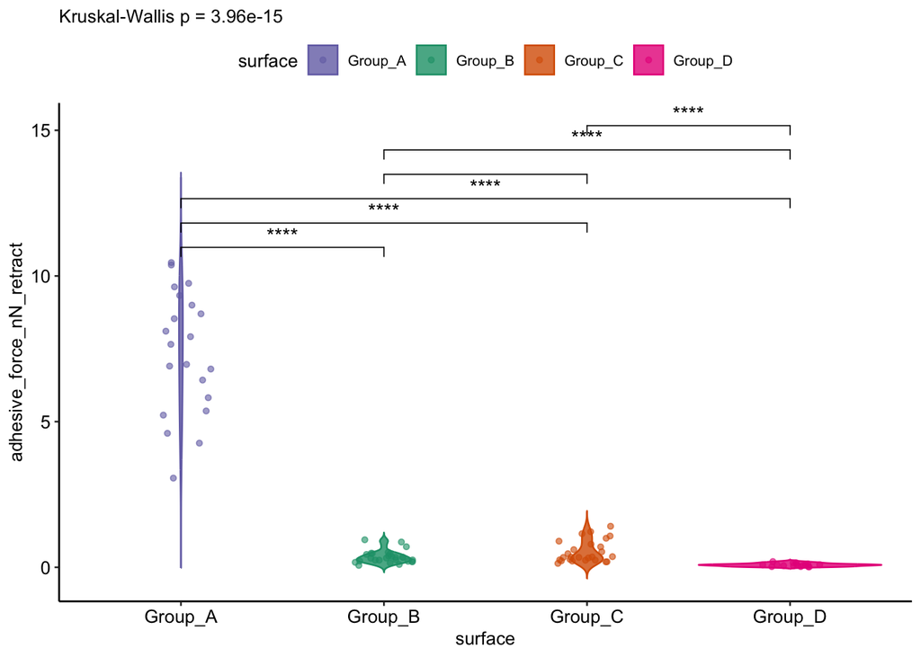

```r
plot_metric_violin(
  df = test@metadata,
  metric_name = "adhesive_force_nN_retract",
  group_by = "surface",
  color_by = "surface",
  color_map = c(
    Group_B = "#1b9e77",
    Group_C = "#d95f02",
    Group_A = "#7570b3",
    Group_D = "#e7298a"
  ),
  global_test = "kruskal",
  pairwise_test = "wilcox"
)
```

The function also allows users to specify which pairwise comparisons to perform so that only relevant comparisons are made and the plot is not overcrowded with significance annotations. Here, we compare Group_A with each of the other three groups.

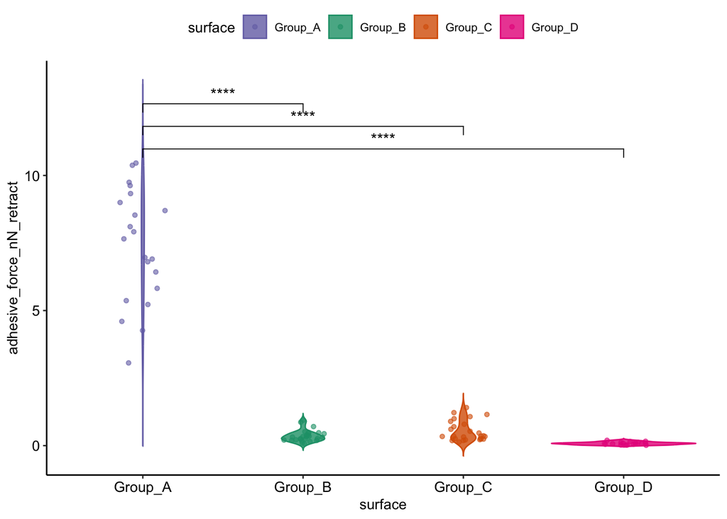

```r
plot_metric_violin(
  df = test@metadata,
  metric_name = "adhesive_force_nN_retract",
  group_by = "surface",
  color_by = "surface",
  color_map = c(
    Group_B = "#1b9e77",
    Group_C = "#d95f02",
    Group_A = "#7570b3",
    Group_D = "#e7298a"
  ),
  global_test = "none", # do not perform global test, only do pairwise comparisons
  pairwise_test = "wilcox",
  pairwise_comparisons = list(
    c("Group_A", "Group_D"),
    c("Group_A", "Group_C"),
    c("Group_A", "Group_B")
  )
)
```